[figure not shown]

# Loading liberey

```python
# This Python 3 environment comes with many helpful analytics libraries installed
# It is defined by the kaggle/python Docker image: https://github.com/kaggle/docker-python
# For example, here's several helpful packages to load

import numpy as np # linear algebra
import pandas as pd # data processing, CSV file I/O (e.g. pd.read_csv)

# Input data files are available in the read-only "../input/" directory
# For example, running this (by clicking run or pressing Shift+Enter) will list all files under the input directory

import os
for dirname, _, filenames in os.walk('/kaggle/input'):
    for filename in filenames:
        print(os.path.join(dirname, filename))

# You can write up to 20GB to the current directory (/kaggle/working/) that gets preserved as output when you create a version using "Save & Run All"
# You can also write temporary files to /kaggle/temp/, but they won't be saved outside of the current session

%matplotlib inline
import matplotlib.pyplot as plt

import seaborn as sns

from IPython.display import display, Markdown, Image
```

```
/kaggle/input/nft-collections-by-sales-volume/NFT_Top_Collections.csv
```

```python
import warnings
warnings.filterwarnings("ignore")
```

## Loading data

```python
NFT_df=pd.read_csv('../input/nft-collections-by-sales-volume/NFT_Top_Collections.csv')
NFT_df2=NFT_df.copy()

NFT_df.sample(5)
```

|  | Index | Name | Volume | Volume_USD | Market_Cap | Market_Cap_USD | Sales | Floor_Price | Floor_Price_USD | Average_Price | Average_Price_USD | Owners | Assets | Owner_Asset_Ratio | Category | Website | Logo |
| --- | --- | --- | --- | --- | --- | --- | --- | --- | --- | --- | --- | --- | --- | --- | --- | --- | --- |
| 406 | 406 | Space Sharks | 9.84 | 1444.7088 | 53.295 | 7824.7719 | 80 | 0.10 | 14.6820 | 0.123000 | 18.058860 | 44 | 102 | 43.14 | Collectibles,Art,PFP,2D | www.spacesharks.club | https://content.solsea.io/files/thumbnail/1638... |
| 289 | 289 | ThePocketBitcoinBand | 19.50 | 2862.9900 | 75.500 | 11084.9100 | 38 | 0.50 | 73.4100 | 0.513158 | 75.341842 | 7 | 151 | 4.64 | Music,Art,Collectibles,Drawing | https://linktr.ee/thebitcoinband | https://content.solsea.io/files/thumbnail/1637... |
| 131 | 131 | Non Friendly Types | 96.19 | 14122.6158 | 0.000 | 0.0000 | 47 | 1.41 | 207.0162 | 2.046596 | 300.481187 | 9 | 16 | 56.25 | NaN | https://instagram.com/nonfriendlytypes | https://content.solsea.io/files/thumbnail/1632... |
| 319 | 319 | Soulless | 16.46 | 2416.6572 | 0.000 | 0.0000 | 10 | 0.08 | 11.7456 | 1.646000 | 241.665720 | 20 | 13 | NaN | NaN | https://www.soulless.io | https://content.solsea.io/files/thumbnail/1633... |
| 144 | 144 | The Tower | 84.31 | 12378.3942 | 0.000 | 0.0000 | 21 | 1.20 | 176.1840 | 4.014762 | 589.447343 | 11 | 13 | 84.62 | NaN | https://towerdao.com/ | https://content.solsea.io/files/thumbnail/1635... |

```python
print(f'total number of rows {NFT_df.shape[0]},\nTotal number of columns {NFT_df.shape[0]}')
```

[output not shown]

how many unique name?

```python
print(f'total no. of unique names {NFT_df["Name"].nunique()}')
```

```
total no. of unique names 592
```

```python
print('columes have how many unique values/rows')
NFT_df.nunique()
```

```
columes have how many unique values/rows
```

```
Index                592
Name                 592
Volume               522
Volume_USD           522
Market_Cap           266
Market_Cap_USD       266
Sales                217
Floor_Price          129
Floor_Price_USD      129
Average_Price        546
Average_Price_USD    546
Owners               149
Assets               219
Owner_Asset_Ratio    375
Category             261
Website              460
Logo                 591
dtype: int64
```

```python
NFT_df.info()
```

```
<class 'pandas.core.frame.DataFrame'>
RangeIndex: 592 entries, 0 to 591
Data columns (total 17 columns):
 #   Column             Non-Null Count  Dtype
---  ------             --------------  -----
 0   Index              592 non-null    int64
 1   Name               592 non-null    object
 2   Volume             592 non-null    float64
 3   Volume_USD         592 non-null    float64
 4   Market_Cap         592 non-null    float64
 5   Market_Cap_USD     592 non-null    float64
 6   Sales              592 non-null    int64
 7   Floor_Price        544 non-null    float64
 8   Floor_Price_USD    544 non-null    float64
 9   Average_Price      592 non-null    float64
 10  Average_Price_USD  592 non-null    float64
 11  Owners             592 non-null    int64
 12  Assets             592 non-null    int64
 13  Owner_Asset_Ratio  543 non-null    float64
 14  Category           310 non-null    object
 15  Website            481 non-null    object
 16  Logo               591 non-null    object
dtypes: float64(9), int64(4), object(4)
memory usage: 78.8+ KB
```

```python
display(Markdown('### top 5 `NFT` have high `Owner_Asset_Ratio`'))
# display(NFT_df2.sort_values(by='Owner_Asset_Ratio',ascending=False).head(5))
display(NFT_df2.sort_values(by='Owner_Asset_Ratio',ascending=False).head(5).style.set_properties(**{'background-color': '#00ffa2'}, subset='Owner_Asset_Ratio'))



display(Markdown('### top 5 `NFT` have high `Sales`'))
# display(NFT_df2.sort_values(by='Sales',ascending=False).head(5))
display(NFT_df2.sort_values(by='Sales',ascending=False).head(5).style.set_properties(**{'background-color': '#00ff04'}, subset='Sales'))

display(Markdown('### top 5 `NFT` have high `Volume`'))
# display(NFT_df2.sort_values(by='Volume',ascending=False).head(5))
display(NFT_df2.sort_values(by='Volume',ascending=False).head(5).style.set_properties(**{'background-color': '#ffffb3'}, subset='Volume'))

display(Markdown('### top 5 `NFT` have high `market_cap`'))
# display(NFT_df2.sort_values(by='Market_Cap',ascending=False).head(5))
display(NFT_df2.sort_values(by='Market_Cap',ascending=False).head(5).style.set_properties(**{'background-color': '#ee00ff'}, subset='Market_Cap'))
```

top 5 `NFT` have high `Owner_Asset_Ratio`

|  | Index | Name | Volume | Volume_USD | Market_Cap | Market_Cap_USD | Sales | Floor_Price | Floor_Price_USD | Average_Price | Average_Price_USD | Owners | Assets | Owner_Asset_Ratio | Category | Website | Logo |
| --- | --- | --- | --- | --- | --- | --- | --- | --- | --- | --- | --- | --- | --- | --- | --- | --- | --- |
| 219 | 219 | HalászÚr | 37.100000 | 5447.022000 | 3.000000 | 440.460000 | 60 | 12.000000 | 1761.840000 | 0.618333 | 90.783700 | 3 | 3 | 100.000000 | Digital,Privilege,Art,Collectibles,Graphics | https://halaszur.hu | https://content.solsea.io/files/thumbnail/1639676251078-431108515.jpg |
| 421 | 422 | ULTIMUM | 9.000000 | 1321.380000 | 0.000000 | 0.000000 | 3 | nan | nan | 3.000000 | 440.460000 | 1 | 1 | 100.000000 | Art | www.keezerfeld.com | https://content.solsea.io/files/thumbnail/1638485116925-334187619.jpg |
| 543 | 549 | Solanum Nigrum | 4.500000 | 660.690000 | 0.000000 | 0.000000 | 18 | 1.000000 | 146.820000 | 0.250000 | 36.705000 | 2 | 2 | 100.000000 | nan | https://www.bluemoon-nft.ch/ | https://content.solsea.io/files/thumbnail/1637698232901-616357476-solsea-icon.png |
| 385 | 385 | LearnToApe Meerkatsu | 11.000000 | 1615.020000 | 0.000000 | 0.000000 | 8 | 6.000000 | 880.920000 | 1.375000 | 201.877500 | 1 | 1 | 100.000000 | Digital,Metaverse,Art,Collectibles,2D,Drawing | nan | https://content.solsea.io/files/thumbnail/1641043612459-749628990.png |
| 387 | 387 | MonkeyBall | 10.900000 | 1600.338000 | 0.000000 | 0.000000 | 3 | 9.000000 | 1321.380000 | 3.633333 | 533.446000 | 8 | 8 | 100.000000 | nan | monkeyball.com | https://content.solsea.io/files/thumbnail/1641488469416-677870316.png |

top 5 `NFT` have high `Sales`

|  | Index | Name | Volume | Volume_USD | Market_Cap | Market_Cap_USD | Sales | Floor_Price | Floor_Price_USD | Average_Price | Average_Price_USD | Owners | Assets | Owner_Asset_Ratio | Category | Website | Logo |
| --- | --- | --- | --- | --- | --- | --- | --- | --- | --- | --- | --- | --- | --- | --- | --- | --- | --- |
| 7 | 7 | Megalodon Rogue Shark Tooth | 2116.610000 | 310760.680200 | 60.050375 | 8816.596058 | 5229 | 0.040000 | 5.872800 | 0.404783 | 59.430231 | 946 | 1309 | 72.270000 | nan | https://t.co/ra8GsIsSz7?amp=1 | https://content.solsea.io/files/thumbnail/1635431310376-188827088-Q1-6BRWp_400x400.jpg |
| 27 | 27 | Solameleon | 659.260000 | 96792.553200 | 294.057143 | 43173.469710 | 4980 | 0.050000 | 7.341000 | 0.132382 | 19.436256 | 2041 | 3320 | 61.480000 | Collectibles | https://www.solameleon.com/ | https://content.solsea.io/files/thumbnail/1633595689457-739048017-sm-512x512.png |
| 19 | 19 | PixTapes | 813.650000 | 119460.093000 | 470.374468 | 69060.379400 | 4596 | 0.100000 | 14.682000 | 0.177034 | 25.992187 | 706 | 1242 | 56.840000 | Art,Music,Collectibles | https://pixtapes.com | https://content.solsea.io/files/thumbnail/1635523689431-454856821-05516 - Usher - Love in this Club.jpg |
| 10 | 10 | Crypto Idolz - Butts | 1756.290000 | 257858.497800 | 910.915461 | 133740.608000 | 2906 | 0.240000 | 35.236800 | 0.604367 | 88.733138 | 413 | 847 | 48.760000 | nan | https://cryptoidolz.com/ | https://content.solsea.io/files/thumbnail/1635528818581-197912343-test (3).png |
| 1 | 1 | Skeleton Crew Skulls | 11381.250000 | 1670995.125000 | 106.656000 | 15659.233920 | 2075 | 0.670000 | 98.369400 | 5.484940 | 805.298855 | 103 | 132 | 78.030000 | nan | https://skeletoncrew.rip/ | https://content.solsea.io/files/thumbnail/1633080381187-181516172-Solsea Profile Image@2x.png |

top 5 `NFT` have high `Volume`

|  | Index | Name | Volume | Volume_USD | Market_Cap | Market_Cap_USD | Sales | Floor_Price | Floor_Price_USD | Average_Price | Average_Price_USD | Owners | Assets | Owner_Asset_Ratio | Category | Website | Logo |
| --- | --- | --- | --- | --- | --- | --- | --- | --- | --- | --- | --- | --- | --- | --- | --- | --- | --- |
| 0 | 0 | basis.markets | 27256.630000 | 4001818.417000 | 708.145455 | 103969.915600 | 366 | 39.500000 | 5799.390000 | 74.471667 | 10933.930100 | 12 | 16 | 75.000000 | Collectibles,Digital,Privilege | https://basis.markets/ | https://content.solsea.io/files/thumbnail/1636669983973-23915727-basis-markets-banner-design-01.jpg |
| 1 | 1 | Skeleton Crew Skulls | 11381.250000 | 1670995.125000 | 106.656000 | 15659.233920 | 2075 | 0.670000 | 98.369400 | 5.484940 | 805.298855 | 103 | 132 | 78.030000 | nan | https://skeletoncrew.rip/ | https://content.solsea.io/files/thumbnail/1633080381187-181516172-Solsea Profile Image@2x.png |
| 2 | 2 | Flippies | 6732.190000 | 988420.135800 | 1663.863158 | 244288.388800 | 1504 | 0.800000 | 117.456000 | 4.476190 | 657.194239 | 905 | 1638 | 55.250000 | nan | https://www.flippies.art/ | https://content.solsea.io/files/thumbnail/1632312299559-878440662-FlippiesOriginal02.png |
| 3 | 3 | Meerkat Millionaires Country Club | 3734.760000 | 548337.463200 | 90.275000 | 13254.175500 | 395 | 3.790000 | 556.447800 | 9.455089 | 1388.196109 | 19 | 23 | 82.610000 | nan | https://meerkatmillionaires.club/ | https://content.solsea.io/files/thumbnail/1632759644698-41570094-kkjewfw - Meerkat Millionaire.png |
| 4 | 4 | Stylish Studs | 3191.150000 | 468524.643000 | 165.000000 | 24225.300000 | 729 | 4.300000 | 631.326000 | 4.377435 | 642.694984 | 28 | 50 | 56.000000 | nan | https://stylishstuds.io | https://content.solsea.io/files/thumbnail/1632756712180-920281342-StylishStuds_500x500 - Ian Cummings.png |

top 5 `NFT` have high `market_cap`

|  | Index | Name | Volume | Volume_USD | Market_Cap | Market_Cap_USD | Sales | Floor_Price | Floor_Price_USD | Average_Price | Average_Price_USD | Owners | Assets | Owner_Asset_Ratio | Category | Website | Logo |
| --- | --- | --- | --- | --- | --- | --- | --- | --- | --- | --- | --- | --- | --- | --- | --- | --- | --- |
| 5 | 5 | I'M AIKO | 2904.700000 | 426468.054000 | 2530.877143 | 371583.382100 | 1411 | 1.200000 | 176.184000 | 2.058611 | 302.245254 | 599 | 1206 | 49.670000 | Art,Collectibles,Graphics,2D,Image | https://aiko.io | https://content.solsea.io/files/thumbnail/1633727219959-29519567-aiko-avatar.png |
| 2 | 2 | Flippies | 6732.190000 | 988420.135800 | 1663.863158 | 244288.388800 | 1504 | 0.800000 | 117.456000 | 4.476190 | 657.194239 | 905 | 1638 | 55.250000 | nan | https://www.flippies.art/ | https://content.solsea.io/files/thumbnail/1632312299559-878440662-FlippiesOriginal02.png |
| 43 | 43 | CoinCards (Solana) | 422.440000 | 62022.640800 | 1368.147826 | 200871.463800 | 506 | 0.300000 | 44.046000 | 0.834862 | 122.574389 | 56 | 860 | 6.510000 | Digital,Art,Collectibles,Trading Cards,3D,Video | nan | https://content.solsea.io/files/thumbnail/1638660905228-840022049.png |
| 6 | 6 | Crypto Idolz | 2315.740000 | 339996.946800 | 1168.041981 | 171491.923700 | 1418 | 0.600000 | 88.092000 | 1.633103 | 239.772177 | 244 | 529 | 46.120000 | nan | https://cryptoidolz.com/ | https://content.solsea.io/files/thumbnail/1632483368175-722908038-logo small - Cry Ido.png |
| 9 | 9 | Meta Waifus | 1844.590000 | 270822.703800 | 989.491267 | 145277.107800 | 1156 | 1.270000 | 186.461400 | 1.595666 | 234.275695 | 376 | 643 | 58.480000 | 3D,PFP,Metaverse,Art,Collectibles | https://metawaifus.com | https://content.solsea.io/files/thumbnail/1637106844666-870870235-logo.jpg |

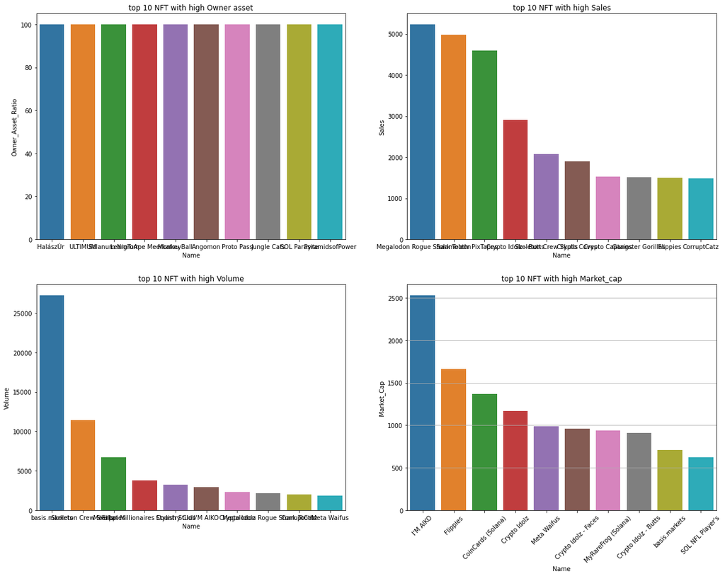

```python
owner_asset=NFT_df2.sort_values(by='Owner_Asset_Ratio',ascending=False,).head(10)
owner_asset=owner_asset.reset_index()
sales=NFT_df2.sort_values(by='Sales',ascending=False).head(10)
sales=sales.reset_index()
volum=NFT_df2.sort_values(by='Volume',ascending=False).head(10)
volum=volum.reset_index()
market_cap=NFT_df2.sort_values(by='Market_Cap',ascending=False).head(10)
market_cap=market_cap.reset_index()

fig,ax = plt.subplots(2,2,figsize=(20,15),)
plt.xticks(rotation = 45)

v1=sns.barplot(owner_asset['Name'],owner_asset['Owner_Asset_Ratio'],ax = ax[0,0])
v1.set(title='top 10 NFT with high Owner asset')
plt.grid(True)

v2=sns.barplot(sales['Name'],sales['Sales'],ax = ax[0,1])
v2.set(title='top 10 NFT with high Sales')
plt.xticks(rotation = 45)
plt.grid(True)

v3=sns.barplot(volum['Name'],volum['Volume'],ax = ax[1,0])
v3.set(title='top 10 NFT with high Volume')
plt.grid(True)

plt.xticks(rotation = 45)
v4=sns.barplot(market_cap['Name'],market_cap['Market_Cap'],ax = ax[1,1])
v4.set(title='top 10 NFT with high Market_cap')

# sns.title('top 10 NFT')


plt.show()
```

top 10 NFT with high Owner_asset_ratio

[figure not shown]

top 10 NFT with high Sales

[figure not shown]

top 10 NFT with high Volum

[figure not shown]

top 10 NFT with high Market_cap

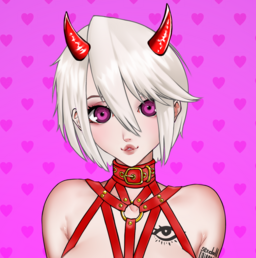

```python
display(Markdown('# top 10 NFT with high Owner_asset_ratio'),Image(owner_asset['Logo'][0],width=200),
        Markdown('# top 10 NFT with  high Sales'),Image(sales['Logo'][0],width=200),
       Markdown('# top 10 NFT with high Volum'),Image(volum['Logo'][0],width=200),
     Markdown('# top 10 NFT with high Market_cap'),Image(market_cap['Logo'][0],width=200))
```

- above cell we see some nan values
- different types of colums have different data type # LO0king how many Null values

```python
NFT_df.isnull().sum()
```

```
Index                  0
Name                   0
Volume                 0
Volume_USD             0
Market_Cap             0
Market_Cap_USD         0
Sales                  0
Floor_Price           48
Floor_Price_USD       48
Average_Price          0
Average_Price_USD      0
Owners                 0
Assets                 0
Owner_Asset_Ratio     49
Category             282
Website              111
Logo                   1
dtype: int64
```

so, we have few columes have null but some columes have many null values **droping columes**

& other columes have few null fill by the **mean**, becuase we have less data so, we can't loss data right now.

# CLEARNING Null values

```python
NFT_df['Floor_Price']=NFT_df['Floor_Price'].replace(np.nan,NFT_df['Floor_Price'].mean())
NFT_df['Floor_Price_USD']=NFT_df['Floor_Price_USD'].replace(np.nan,NFT_df['Floor_Price_USD'].mean())
NFT_df['Owner_Asset_Ratio']=NFT_df['Owner_Asset_Ratio'].replace(np.nan,NFT_df['Owner_Asset_Ratio'].mean())

NFT_df.drop(columns=['Category','Website','Logo','Name'],axis=1,inplace=True)
# NFT_df['Floor_Price'].apply(replace_to_mean )
```

```python
NFT_df.describe()
```

|  | Index | Volume | Volume_USD | Market_Cap | Market_Cap_USD | Sales | Floor_Price | Floor_Price_USD | Average_Price | Average_Price_USD | Owners | Assets | Owner_Asset_Ratio |
| --- | --- | --- | --- | --- | --- | --- | --- | --- | --- | --- | --- | --- | --- |
| count | 592.000000 | 592.000000 | 5.920000e+02 | 592.000000 | 592.000000 | 592.000000 | 592.000000 | 592.000000 | 592.000000 | 592.000000 | 592.000000 | 592.000000 | 592.000000 |
| mean | 296.547297 | 197.548885 | 2.900413e+04 | 45.134817 | 6626.693810 | 164.491554 | 2.423015 | 355.747019 | 2.373566 | 348.486991 | 53.731419 | 116.694257 | 54.385672 |
| std | 172.520622 | 1283.031435 | 1.883747e+05 | 179.327166 | 26328.814578 | 451.321395 | 18.194978 | 2671.386667 | 15.035229 | 2207.472329 | 133.893752 | 251.598765 | 26.462467 |
| min | 0.000000 | 0.000000 | 0.000000e+00 | 0.000000 | 0.000000 | 0.000000 | 0.020000 | 2.936400 | 0.000000 | 0.000000 | 0.000000 | 0.000000 | 0.260000 |
| 25% | 147.750000 | 7.300000 | 1.071786e+03 | 0.000000 | 0.000000 | 11.000000 | 0.130000 | 19.086600 | 0.306029 | 44.931155 | 4.000000 | 10.000000 | 36.065000 |
| 50% | 295.500000 | 18.595000 | 2.730118e+03 | 0.000000 | 0.000000 | 35.000000 | 0.400000 | 58.728000 | 0.720412 | 105.770928 | 15.000000 | 38.000000 | 54.480000 |
| 75% | 444.250000 | 80.825000 | 1.186673e+04 | 21.841974 | 3206.838576 | 107.250000 | 1.200000 | 176.184000 | 1.596750 | 234.434771 | 44.000000 | 102.250000 | 71.085000 |
| max | 599.000000 | 27256.630000 | 4.001818e+06 | 2530.877143 | 371583.382100 | 5229.000000 | 400.000000 | 58728.000000 | 347.500000 | 51019.950000 | 2041.000000 | 3320.000000 | 100.000000 |

# Multivarient Analysis

let's see some correlation between features

## correlation higher then 0.4

|  | Index | Volume | Volume_USD | Market_Cap | Market_Cap_USD | Sales | Floor_Price | Floor_Price_USD | Average_Price | Average_Price_USD | Owners | Assets | Owner_Asset_Ratio |
| --- | --- | --- | --- | --- | --- | --- | --- | --- | --- | --- | --- | --- | --- |
| Index | 1.0 | NaN | NaN | NaN | NaN | NaN | NaN | NaN | NaN | NaN | NaN | NaN | NaN |
| Volume | NaN | 1.0 | 1.0 | NaN | NaN | NaN | NaN | NaN | NaN | NaN | NaN | NaN | NaN |
| Volume_USD | NaN | 1.0 | 1.0 | NaN | NaN | NaN | NaN | NaN | NaN | NaN | NaN | NaN | NaN |
| Market_Cap | NaN | NaN | NaN | 1.000000 | 1.000000 | 0.404380 | NaN | NaN | NaN | NaN | 0.419220 | 0.539007 | NaN |
| Market_Cap_USD | NaN | NaN | NaN | 1.000000 | 1.000000 | 0.404380 | NaN | NaN | NaN | NaN | 0.419220 | 0.539007 | NaN |
| Sales | NaN | NaN | NaN | 0.404380 | 0.404380 | 1.000000 | NaN | NaN | NaN | NaN | 0.811492 | 0.753750 | NaN |
| Floor_Price | NaN | NaN | NaN | NaN | NaN | NaN | 1.0 | 1.0 | NaN | NaN | NaN | NaN | NaN |
| Floor_Price_USD | NaN | NaN | NaN | NaN | NaN | NaN | 1.0 | 1.0 | NaN | NaN | NaN | NaN | NaN |
| Average_Price | NaN | NaN | NaN | NaN | NaN | NaN | NaN | NaN | 1.0 | 1.0 | NaN | NaN | NaN |
| Average_Price_USD | NaN | NaN | NaN | NaN | NaN | NaN | NaN | NaN | 1.0 | 1.0 | NaN | NaN | NaN |
| Owners | NaN | NaN | NaN | 0.419220 | 0.419220 | 0.811492 | NaN | NaN | NaN | NaN | 1.000000 | 0.909380 | NaN |
| Assets | NaN | NaN | NaN | 0.539007 | 0.539007 | 0.753750 | NaN | NaN | NaN | NaN | 0.909380 | 1.000000 | NaN |
| Owner_Asset_Ratio | NaN | NaN | NaN | NaN | NaN | NaN | NaN | NaN | NaN | NaN | NaN | NaN | 1.0 |

```
heatmap for grather & equal to 0.4
```

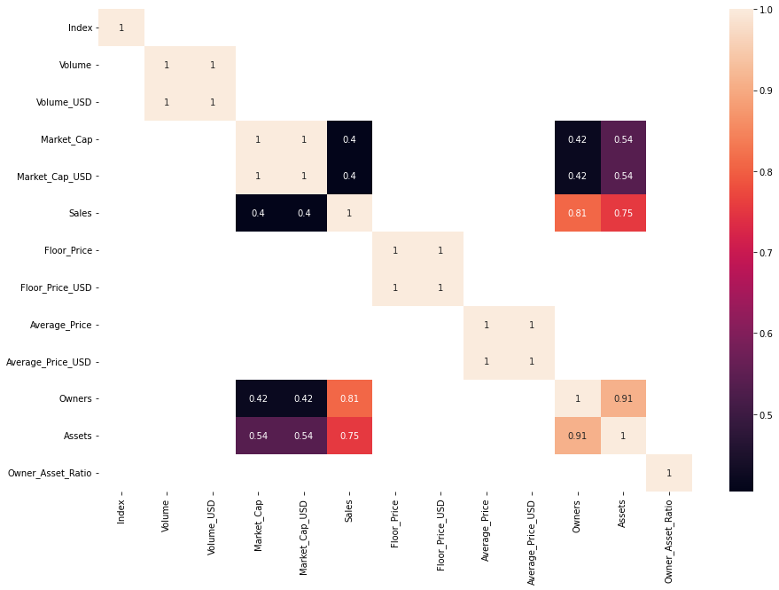

```python
plt.figure(figsize=(15,10))

nft_corr=NFT_df.corr()
display(nft_corr[nft_corr>=0.4])
print('heatmap for grather & equal to 0.4 ')
display(sns.heatmap(nft_corr[nft_corr>=0.4],annot=True))
plt.show()
```

here you see few features correlated to other features

let's pick those columns for after analysis `[Sales, Market_Cap_USD, Market_Cap, Owner, Assets, Sales]`

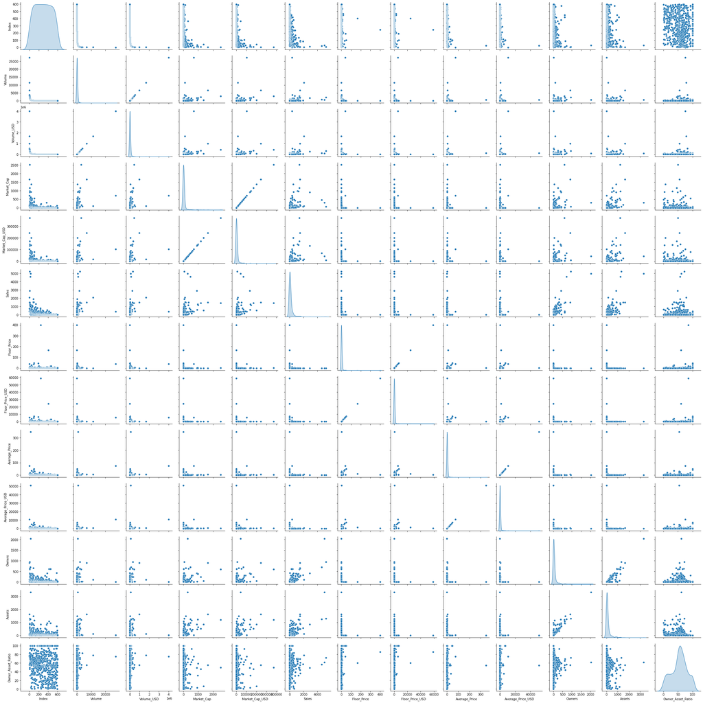

```python
# sns.pairplot(NFT_df)
# plt.show()

g = sns.pairplot(NFT_df, diag_kind="kde")
# g.map_lower(sns.kdeplot, levels=4, color=".2")
```

how far correleted data from mean & median in correlation each column

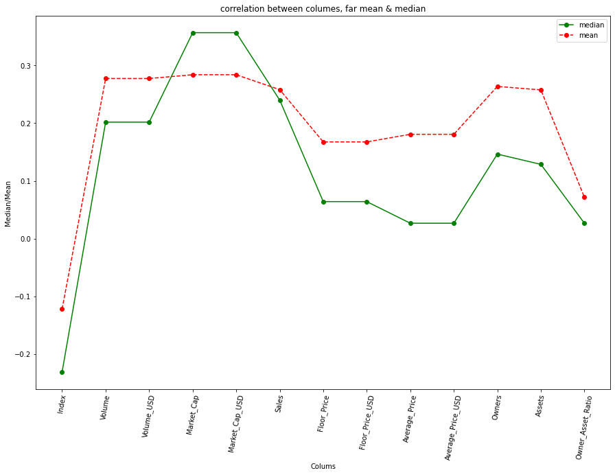

```python
plt.figure(figsize=(15,10))
plt.plot(nft_corr.median(),'g-o',label='median')
plt.plot(np.mean(nft_corr),'r--o',label='mean')
plt.ylabel('Median/Mean')
plt.xlabel('Colums')
plt.title('correlation between columes, far mean & median')
plt.xticks(rotation = 80)
plt.legend()
plt.show()
```

```python
NFT_df.columns
```

```
Index(['Index', 'Volume', 'Volume_USD', 'Market_Cap', 'Market_Cap_USD',
       'Sales', 'Floor_Price', 'Floor_Price_USD', 'Average_Price',
       'Average_Price_USD', 'Owners', 'Assets', 'Owner_Asset_Ratio'],
      dtype='object')
```

`Sales, Market_Cap_USD, Market_Cap, Owner, Assets, Sales` let's here to some analysis on this features

```python
NFT_df.sample(2)
```

|  | Index | Volume | Volume_USD | Market_Cap | Market_Cap_USD | Sales | Floor_Price | Floor_Price_USD | Average_Price | Average_Price_USD | Owners | Assets | Owner_Asset_Ratio |
| --- | --- | --- | --- | --- | --- | --- | --- | --- | --- | --- | --- | --- | --- |
| 484 | 486 | 5.99 | 879.4518 | 10.800000 | 1585.6560 | 48 | 0.04 | 5.8728 | 0.124792 | 18.321912 | 39 | 72 | 54.17 |
| 19 | 19 | 813.65 | 119460.0930 | 470.374468 | 69060.3794 | 4596 | 0.10 | 14.6820 | 0.177034 | 25.992187 | 706 | 1242 | 56.84 |

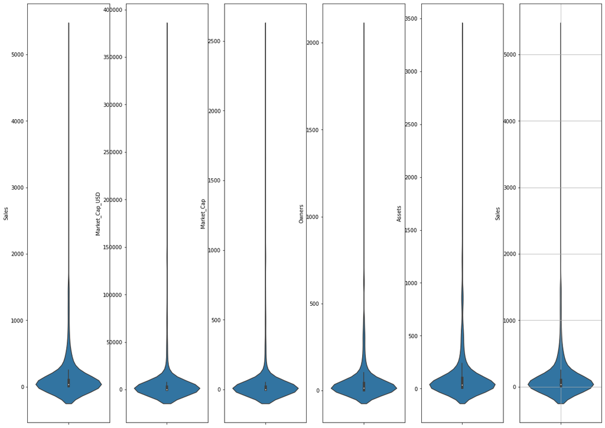

```python
fig,ax = plt.subplots(1,6,figsize=(20,15))
sns.violinplot(y =NFT_df.Sales ,data = NFT_df,ax = ax[0])
sns.violinplot(y =NFT_df.Market_Cap_USD ,data = NFT_df,ax = ax[1])
sns.violinplot(y =NFT_df.Market_Cap ,data = NFT_df,ax = ax[2])
sns.violinplot(y =NFT_df.Owners,data = NFT_df,ax = ax[3])
sns.violinplot(y =NFT_df.Assets,data = NFT_df,ax = ax[4])
sns.violinplot(y =NFT_df.Sales,data = NFT_df,ax = ax[5])

plt.grid(True)
plt.show()
```

all above plote are `positive-skew` & `have many outlier` hight & width of the voilent is high, high mean also same size of std high probabilty density in the bignning that mean, most of chance people around the median valuse

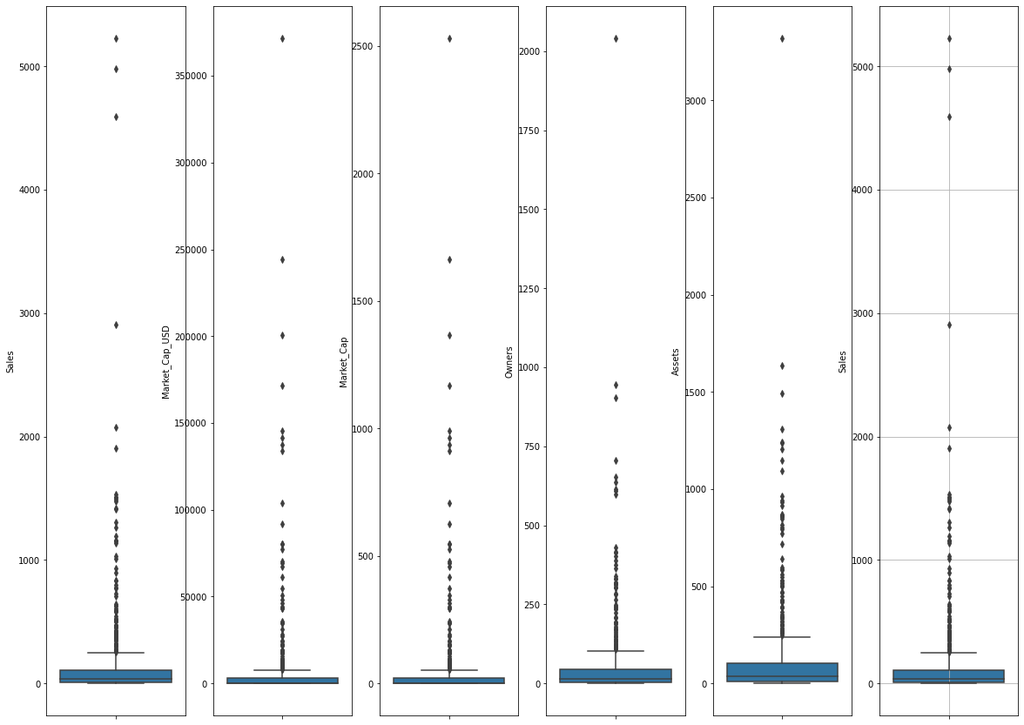

```python
fig,ax = plt.subplots(1,6,figsize=(20,15))
sns.boxplot(y =NFT_df.Sales ,data = NFT_df,ax = ax[0])
sns.boxplot(y =NFT_df.Market_Cap_USD ,data = NFT_df,ax = ax[1])
sns.boxplot(y =NFT_df.Market_Cap ,data = NFT_df,ax = ax[2])
sns.boxplot(y =NFT_df.Owners,data = NFT_df,ax = ax[3])
sns.boxplot(y =NFT_df.Assets,data = NFT_df,ax = ax[4])
sns.boxplot(y =NFT_df.Sales,data = NFT_df,ax = ax[5])

plt.grid(True)
plt.show()
```

in few cases , some nft sales many time & that the resone that market_cap high & they have so many owners

# Conclusion

This (Analysis) Notebook part of my end-to-end project, I am using this Notebook/Dataset for creating A.I to create Art to NFT. If you have any suggestions on how to improve myself or my code please let me know on the comment section. and using online resorces :)